# PPG Paint Colors: Final Project

### Coefficient Plot

**Visualize the coefficient summaries for the top 3 models.**

[figure not shown]

```r
Model_7 %>%
  coefplot::coefplot() +
  theme_bw()
```

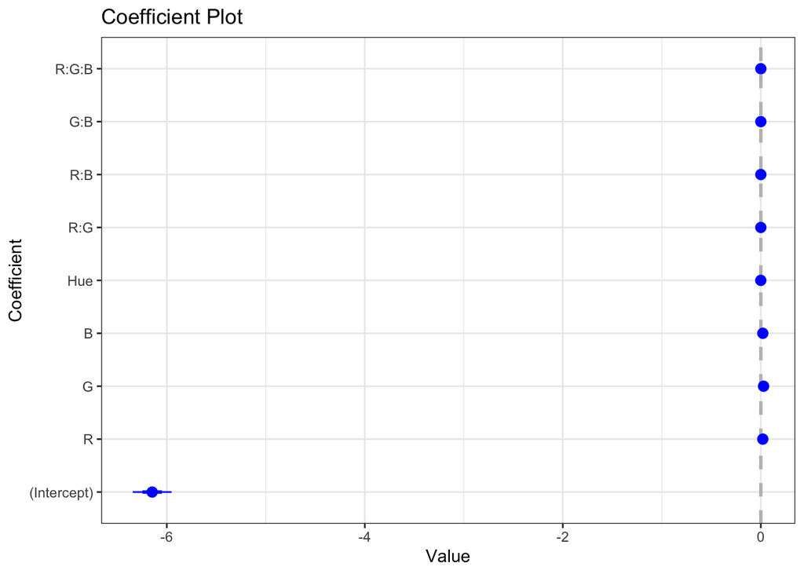

```r
Model_9 %>%
  coefplot::coefplot() +
  theme_bw()
```

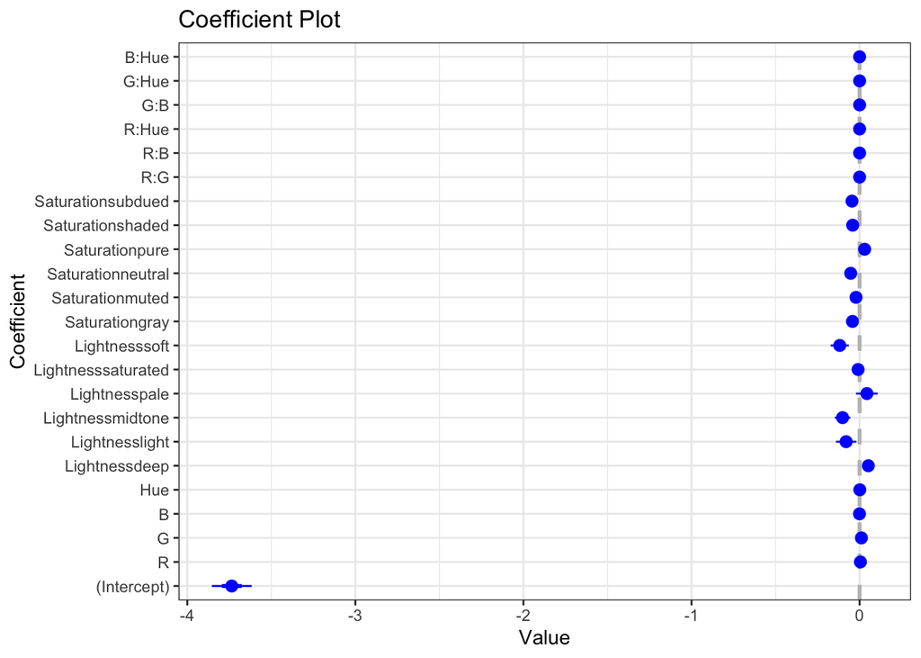

```r
Model_6 %>%
  coefplot::coefplot() +
  theme_bw()
```

- Each model contains some significant coefficients, but it looks like majority of them are non-significant.
- For the “Interactions of basis functions with other basis functions” (`Model_9`) the coefficients are very small.

### Important Features

**Extract significant coefficients and arrange by overall score.**

# Variable importance for Models

```r
var_importance_results <- varImp(Model_6)
result_data <- data.frame(Variable = rownames(var_importance_results), Importance = var_importance_results$Overall)
result_data <- result_data[order(-result_data$Importance), ]
print(result_data)
```

```
##              Variable Importance
## 2                   G 14.4013007
## 1                   R 12.6104427
## 20                G:B  8.5589370
## 17                R:G  5.7421925
## 19              R:Hue  5.7197028
## 13  Saturationneutral  4.7265694
## 7    Lightnessmidtone  4.3828944
## 10      Lightnesssoft  4.3754351
## 16  Saturationsubdued  4.3389855
## 5       Lightnessdeep  4.0350054
## 15   Saturationshaded  3.8104676
## 21              G:Hue  3.1458328
## 11     Saturationgray  3.1415983
## 14     Saturationpure  2.8419160
## 6      Lightnesslight  2.6516615
## 12    Saturationmuted  2.1007439
## 18                R:B  1.4534423
## 8       Lightnesspale  1.3438355
## 4                 Hue  0.7683861
## 3                   B  0.7375034
## 22              B:Hue  0.6595753
## 9  Lightnesssaturated  0.5042391
```

Input G seemns to be the most important.

```r
var_importance_results <- varImp(Model_7)
result_data <- data.frame(Variable = rownames(var_importance_results), Importance = var_importance_results$Overall)
result_data <- result_data[order(-result_data$Importance), ]
print(result_data)
```

```
##                     Variable  Importance
## 73      Lightnessmidtone:R:G 9.331011824
## 6              Lightnesssoft 8.591382998
## 3           Lightnessmidtone 7.882902156
## 76         Lightnesssoft:R:G 7.847421864
## 14                         G 7.581590811
## 34           Lightnesssoft:G 7.547957269
## 75    Lightnesssaturated:R:G 7.488146011
## 4              Lightnesspale 7.329837838
## 5         Lightnesssaturated 7.175153595
## 31        Lightnessmidtone:G 6.651775057
## 2             Lightnesslight 6.450015871
## 27      Lightnesssaturated:R 6.259702775
## 30          Lightnesslight:G 6.233783558
## 25        Lightnessmidtone:R 6.015837409
```

[output cut: 128 more lines]

Interaction of Lightness with R and G seems to be the most important here.

```r
var_importance_results <- varImp(Model_9)
result_data <- data.frame(Variable = rownames(var_importance_results), Importance = var_importance_results$Overall)
result_data <- result_data[order(-result_data$Importance), ]
print(result_data)
```

```
##   Variable Importance
## 2        G  37.789202
## 1        R  33.051521
## 6      R:B  30.460078
## 8    R:G:B  28.908350
## 3        B  26.085233
## 5      R:G  22.011321
## 7      G:B  20.043012
## 4      Hue   1.458691
```

Input G seemns to be the most important.

# Save the models

```r
Model_7 %>% readr::write_rds("Model_7.rds")
Model_6 %>% readr::write_rds("Model_6.rds")
Model_9 %>% readr::write_rds("Model_9.rds")
```